# Week Two, Day 1

Chester Ismay

January 29, 2016

1. Plug in audio
2. Tell them I will be gone February to Anchorage (February 13 - February 17)
- Lectures on Monday, February 15th and Wednesday, February 17th will be in Psych 105
- Joint meeting with other 141 section
- Labs will meet as usual on Tuesday with Andrew at the helm
2. Quiz 1 will be on Friday over Chapter 1 of the text
- Start working on PS2 before Friday to help you prepare for the Quiz on Friday
3. Demo Ella’s lab
4. **Recap**
- Correlation does NOT imply causation
- Causation can only be inferred from randomized experiments (ones that randomly assign treatments to subjects)
- Random sampling allows us to confidently make inferences about populations through collection of representative samples.
4. Today we will be talking about numerical and graphical ways to describe data
- **Draw plots on the board**

| X1 | X2 | X3 | X4 | X5 | X6 | X7 | X8 | X9 | X10 |
| --- | --- | --- | --- | --- | --- | --- | --- | --- | --- |
| 2.08 | 3.16 | 3.87 | 3.73 | 3.42 | 2.99 | 3.13 | 3.11 | 3.17 | 2.88 |

- We denote variables with capital letters
  - e.g., $X$ = Cumulative GPA of Reed students
  - What’s $\mu$? Based on 2014-15 data, $\mu = 3.15$
- We denote specific observations of that variable (the sample data) by small letters
  - e.g., $x_1 = 2.08$, $x_2 = 3.16$, $\cdots$, $x_{10} = 2.88$, — $n = 10$

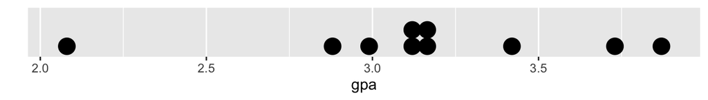

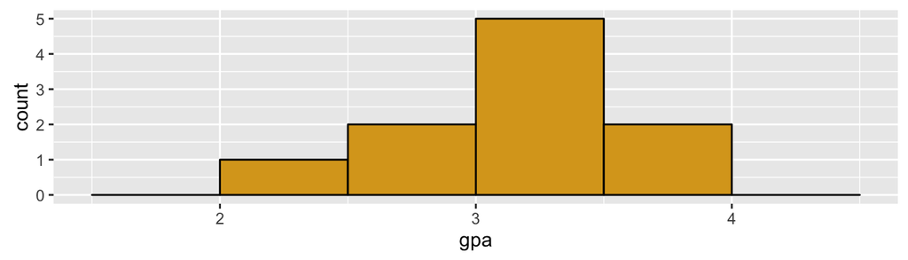

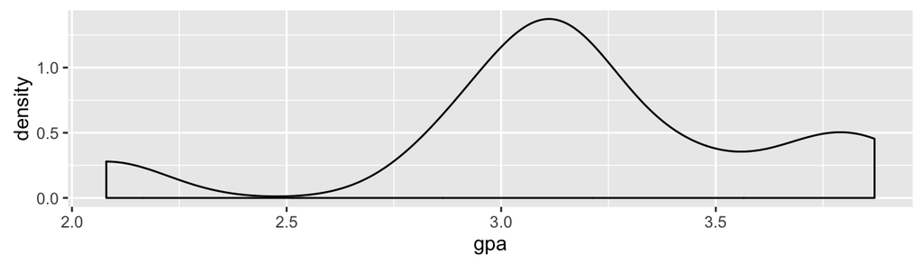

- Area under the curve between any two $x$ values gives the proportion of $y$ values that fall in that given range (integration from calculus)

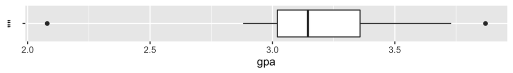

5. Go to slides
- How would we characterize the plots for GPA based on shape?
- Go over Shape slide
6. Go to Plicker question 1
7. Come back to slides
- The Typical Human video
- go through until Plicker 2
8. Go back to slides
- Which line corresponds to mean? Which to median?

**Finish reading over Chapter 1, look over your Lab 1 feedback.**

**We will be discussing describing/manipulating data using the PIPE operator and how to work with data frames in R tomorrow during lab**